# How does a bike-share navigate speedy success?

Mariia Berjoza

August 27, 2024

#### Data Source

The data used in this case-study is referring to this resource. The data has been made available by Motivate International Inc. under this license

Note: The datasets have a different name. For the purposes of this case study I have been using a fictional company name (Cyclistic).

##### Files used:

- 202407-divvy-tripdata.csv
- 202406-divvy-tripdata.csv
- 202405-divvy-tripdata.csv
- 202404-divvy-tripdata.csv
- 202403-divvy-tripdata.csv
- 202402-divvy-tripdata.csv
- 202401-divvy-tripdata.csv
- 202312-divvy-tripdata.csv
- 202311-divvy-tripdata.csv
- 202310-divvy-tripdata.csv
- 202309-divvy-tripdata.csv
- 202308-divvy-tripdata.csv

## Client: Cyclistic

### About company

Cyclistic is a bike-share program that features more than 5,800 bicycles and 600 docking stations. Cyclistic sets itself apart by also offering:

- reclining bikes
- hand tricycles
- cargo bikes

Cyclistic is making bike-share more inclusive to people with disabilities and riders who can’t use a standard two-wheeled bike. The majority of riders opt for traditional bikes; about 8% of riders use the assistive options. Cyclistic users are more likely to ride for leisure, but about 30% use the bikes to commute to work each day.

In 2016, Cyclistic launched a successful bike-share offering. Since then, the program has grown to a fleet of 5,824 bicycles that are geotracked and locked into a network of 692 stations across Chicago. *The bikes can be unlocked from one station and returned to any other station* in the system anytime.

### Marketing program

Cyclistic’s marketing strategy relied on building general awareness and appealing to broad consumer segments. One approach that helped make these things possible was the flexibility of its pricing plans: single-ride passes, full-day passes, and annual memberships. Customers who purchase single-ride or full-day passes are referred to as casual riders. Customers who purchase annual memberships are Cyclistic members.

### Problem

Cyclistic’s finance analysts have concluded that annual members are much more profitable than casual riders. Although the pricing flexibility helps Cyclistic attract more customers, Director of marketing believes that maximizing the number of annual members will be key to future growth. Rather than creating a marketing campaign that targets all-new customers, there is a suggestion to convert casual riders into members. Casual riders are already aware of the Cyclistic program and have chosen Cyclistic for their mobility needs.

## Analysis

### How do annual members and casual riders use Cyclistic bikes differently?

To explore riders behavior, lets check top-100 stations where our riders usually prefer to start their trip.

##### Top-100 start stations (by total amount of rides)

Customers top places are represented in pink colour. Subscribers top are blue and black. Green areas are 50/50. Area size represents the total rides amount.

[interactive chart not shown]

#### Key insights

##### Popular Locations for Casual Riders - Piers and Lakefronts

Near East Side, Grant Park, Museum Campus, South Loop: those locations represent some of the most scenic and culturally rich areas of Chicago, all situated along the lakefront or very close to it.

##### Mixed-Use Areas: Lincoln Park

Lincoln Park is one of Chicago’s most well-known and affluent neighborhoods. It’s characterized by historic homes, tree-lined streets, and a vibrant community with plenty of cultural and recreational amenities. This is a balanced area (50% customers /50% subscribers).

##### Subscribers top: Bridgeport, Business Districts, Workplaces, Residential Neighborhoods

Many of these coordinates are located in or near The Loop and West Loop areas, which are major business districts in Chicago. These areas are densely packed with offices, corporate headquarters, and other workplaces. These are vibrant, well-established residential neighborhoods that are close to downtown but also maintain a residential character. Bridgeport is a mix of residential and cultural spots with a strong local community vibe.

Below we can see top routes

#### Top-10 routes: Customers

[interactive chart not shown]

#### Top-10 routes: Subscribers

[interactive chart not shown]

### Seasonal factor: Rides activity

#### Rides per week

Let’s figure out how customers use bikes on daily basis

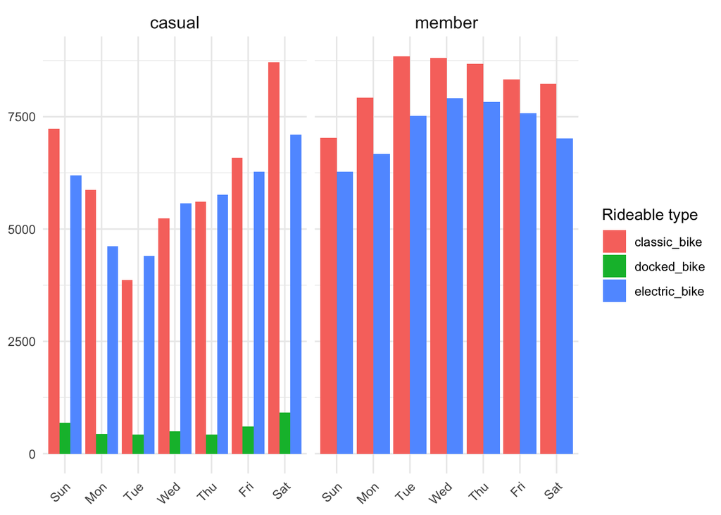

From the diagram above we can see that customers rides amount frows significantly by Saturday and Sunday. Customers are using docked bike as well. At the same time the middle of the week (Tuesday-Thursday) is the busiest for subscribers.

Now let’s check the seasonal factor.

#### Rides per month

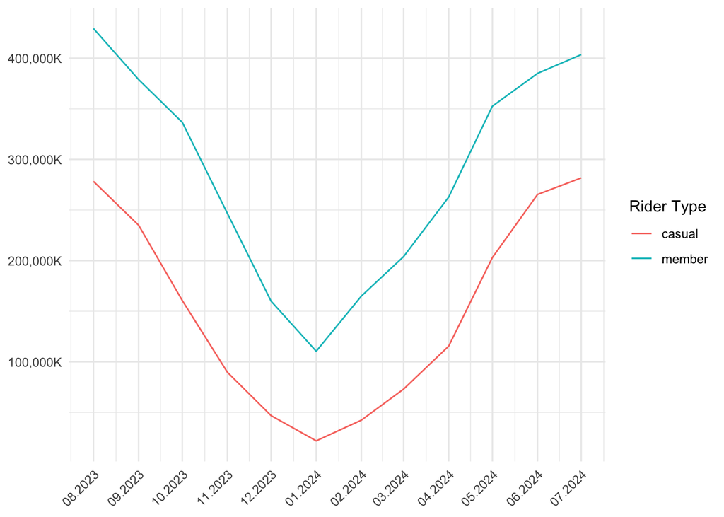

For sure cycling is a seasonal sport. Subscribers and customers rides amount are growing from spring to the end of summer. Minimum rides are in January (However, they are not 0) and maximum is in July-August (the weather is pretty good).

#### Why would casual riders buy Cyclistic annual memberships?

Opposite to subscribers, who are using bike share on daily basis for commuting, Casual riders may be tourists or occasional users who enjoy leisurely rides in picturesque areas. If Cyclistic can offer incentives (e.g., discounts or exclusive access) for frequent rides along most popular scenic routes, casual riders may see value in purchasing an annual membership, even if they are not daily commuters.